# S&P 500 and Equity Returns Project

### Author: Daniel Drangstveit

```python
import numpy as np
import pandas as pd
```

```python
import matplotlib
import matplotlib.pyplot as plt
matplotlib.style.use('ggplot')
%matplotlib inline
```

## Reading S&P 500 data from a CSV file

We start by *reading data from a csv* file of the S&P 500 downloaded from Yahoo! Finance.

Later in this notebook we use `pandas datareader` to download data from Yahoo!Finance directly.

```python
# For ease of use, download GSPC.csv in the same path as this notebook.
sp500 = pd.read_csv('GSPC.csv', header=0, parse_dates=['Date'])
```

```python
sp500 = sp500.set_index('Date')
```

It's always a good idea to look at the data first to confirm that it looks how you expect. Let's use iloc to see the first last 3 rows of the data

```python
sp500.iloc[[0, 1, 2, -3, -2, -1]]
```

| Date | Open | High | Low | Close | Adj Close | Volume |
| --- | --- | --- | --- | --- | --- | --- |
| 1950-01-03 | 16.66 | 16.66 | 16.66 | 16.66 | 16.66 | 1260000 |
| 1950-01-04 | 16.85 | 16.85 | 16.85 | 16.85 | 16.85 | 1890000 |
| 1950-01-05 | 16.93 | 16.93 | 16.93 | 16.93 | 16.93 | 2550000 |
| 2023-03-29 | 3999.53 | 4030.59 | 3999.53 | 4027.81 | 4027.81 | 4145250000 |
| 2023-03-30 | 4046.74 | 4057.85 | 4032.10 | 4050.83 | 4050.83 | 3930860000 |
| 2023-03-31 | 4056.18 | 4110.75 | 4056.18 | 4109.31 | 4109.31 | 2516723000 |

### Plot prices as a timeseries:

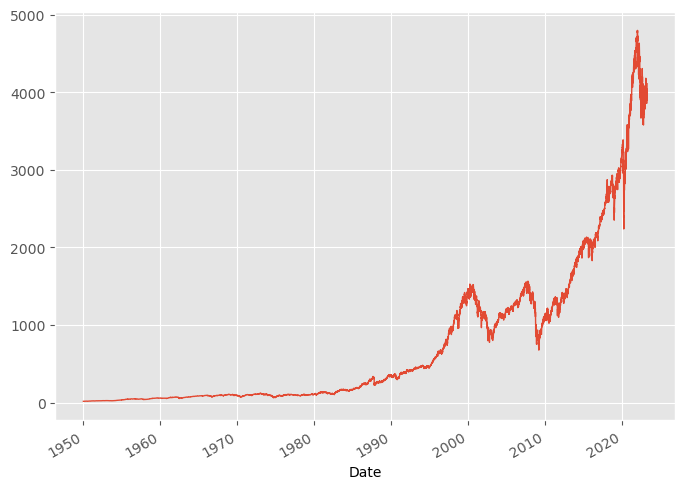

```python
sp500['Adj Close'].plot(figsize=(8, 6), lw=1)
```

```python
# Set a plotting option that will apply to all plots generated during this session
matplotlib.rcParams['figure.figsize'] = (8,6)
```

#### Plot prices as a range of dates:

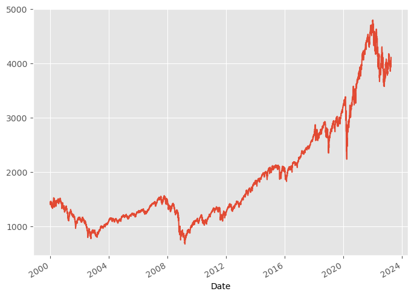

```python
# Plots the adjusted closing price of the S&P 500 since 2000
sp500['Adj Close'].loc['2000-01-01':].plot()
```

## Plots of cumulative returns

How much money would an investor who started with $1 in 1950, have today if they simply bought and held the index?

```python
# Divide the pandas Series object by a value to create a new Series called x
close = sp500['Adj Close']
x = (close / close.iloc[0])
x[:5]
```

```
Date
1950-01-03    1.000000
1950-01-04    1.011405
1950-01-05    1.016206
1950-01-06    1.019208
1950-01-09    1.025210
Name: Adj Close, dtype: float64
```

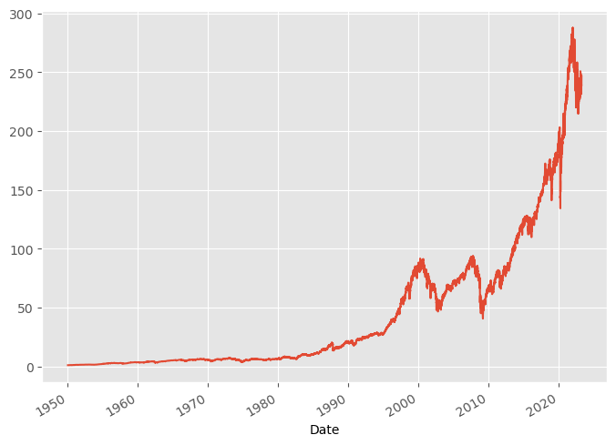

```python
x.plot()
```

How much money would an investor who started with $100 in 1950, have today if they simply bought and held the index?

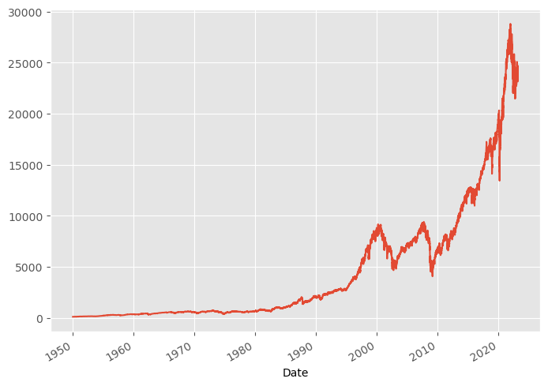

```python
((close / close.iloc[0])*100).plot()
```

Below is a function that has inputs of data, start-date, end-date. The function outputs (returns) a **plot of the cumulative return** over the input time period:

```python
def plot_val(ts, stdt=None, enddt=None):
    stdt, enddt = map(pd.to_datetime, [stdt, enddt])
    if stdt is None:
        stdt = ts.index[0]
    if enddt is None:
        enddt = ts.index[-1]
    df = ts.copy()
    df = df.loc[stdt:enddt]
    return (df['Adj Close'] / df.loc[stdt, 'Adj Close']).plot()
```

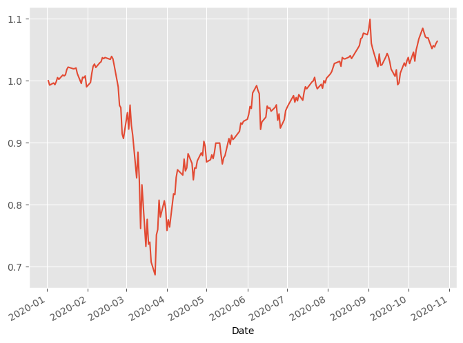

```python
# Calling the function without the stdt and enddt parameters
# plot_val(sp500)

# COVID-19 Crash and Rebound
plot_val(sp500, stdt='2020-01-02', enddt='2020-10-23')
```

## Returns: daily returns based on daily price data

We can calculate a return series from prices using the `.pct_change()` function

**It is important to compute returns based on *Adj Close*, and not just *Close*.**

```python
sp500['ret'] = sp500['Adj Close'].pct_change()
sp500.head()
```

| Date | Open | High | Low | Close | Adj Close | Volume | ret |
| --- | --- | --- | --- | --- | --- | --- | --- |
| 1950-01-03 | 16.66 | 16.66 | 16.66 | 16.66 | 16.66 | 1260000 | NaN |
| 1950-01-04 | 16.85 | 16.85 | 16.85 | 16.85 | 16.85 | 1890000 | 0.011405 |
| 1950-01-05 | 16.93 | 16.93 | 16.93 | 16.93 | 16.93 | 2550000 | 0.004748 |
| 1950-01-06 | 16.98 | 16.98 | 16.98 | 16.98 | 16.98 | 2010000 | 0.002953 |
| 1950-01-09 | 17.08 | 17.08 | 17.08 | 17.08 | 17.08 | 2520000 | 0.005889 |

```python
sp500['ret'].describe()
```

```
count    18430.000000
mean         0.000349
std          0.009951
min         -0.204669
25%         -0.004085
50%          0.000484
75%          0.005054
max          0.115800
Name: ret, dtype: float64
```

```python
sp500['ret'].nlargest(5)
```

```
Date
2008-10-13    0.115800
2008-10-28    0.107890
2020-03-24    0.093828
2020-03-13    0.092871
1987-10-21    0.090994
Name: ret, dtype: float64
```

```python
sp500['ret'].nsmallest(5)
```

```
Date
1987-10-19   -0.204669
2020-03-16   -0.119841
2020-03-12   -0.095113
2008-10-15   -0.090350
2008-12-01   -0.089295
Name: ret, dtype: float64
```

#### Plot of daily S&P500 returns over time:

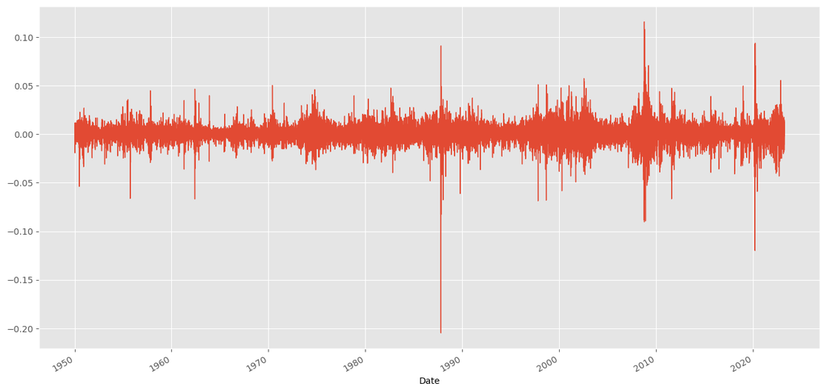

```python
sp500['ret'].plot(figsize=(16,8), lw=1)
```

#### Plot of the distribution of S&P500 retuns - a histogram:

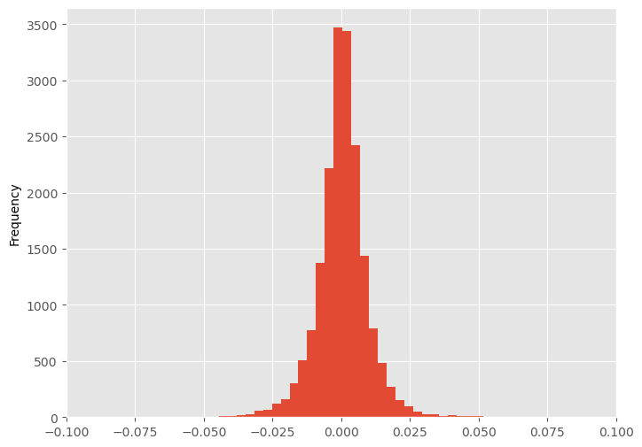

```python
sp500['ret'].plot(kind='hist', bins=100, xlim=(-.1, .1))
```

## Are returns Normally distributed?

At first glance this graph appears to have the familiar bell-shaped curve of the famouse Normal (or Gaussian) distribution. It does not. Returns tend to have far more *outliers* — that is, extreme positive or negative values, than would be expected from a Normal distribution.

One way to see this is using *simulations*. Let's start by repeatedly drawing from a Normal distribution with the same mean and variance as the returns.

We draw random values for variable x: $$x \sim N(0,1)$$ Transform x to y by:

\begin{equation} y = \mu + \sigma x, \end{equation}

So that finally: $$y \sim N(\mu, \sigma^2)$$

Answer: No, because the the extreme high and low returns (the fat tails)

```python
mu = sp500['ret'].mean()
sigma = sp500['ret'].std()

mu, sigma
```

```
(0.0003486612503334682, 0.009950806859666973)
```

1 million *draws* from y ($y = \mu + \sigma x$):

```python
draws = mu + sigma * np.random.randn(1000000)
```

```python
# type(draws)
# draws.shape
draws
```

```
array([-0.0328308 , -0.01094502,  0.00854523, ..., -0.00059186,
        0.0182929 ,  0.00964685])
```

We can verify that the mean and standard deviation of *draws* are what we expect.

```python
draws.mean(), draws.std()
```

```
(0.00033360730755548513, 0.00995156262471097)
```

#### Plot of the normally dist. variable *draws*:

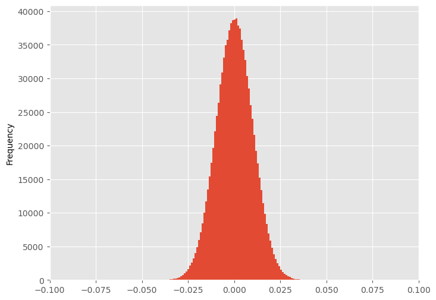

```python
pd.Series(draws).plot(kind='hist', bins=100, xlim=(-.1,.1))
```

Left tail of draws (theoretical returns based on normal dist.):

```python
# draws[draws<-0.04]
# len(draws[draws<-0.04])
print(f'Percent of returns lower than 4: {len(draws[draws<-0.04])/len(draws):.05f}')
```

```
Percent of returns lower than 4: 0.00004
```

Left tail of S&P 500 returns (actual returns):

```python
# sp500['ret'][sp500['ret']<-.04]
# len(sp500[sp500['ret']<-.04])
len(sp500[sp500['ret']<-.04])/len(sp500['ret'])
```

```
0.002929846454343226
```

The true return distribution has far more extreme values — both negative and positive — than a normal distribution would give. In statistics jargon, the return distribution has *fat tails*. A statistical measure of how thick are the tails of a distribution is the *kurtosis*.

$$K(x) = E\left[\left(\frac{x-\mu}{\sigma}\right)^4\right]$$

The kurtosis of a Normally-distributed random variable is 3, so *excess kurtosis* is defined as $K(x)-3$. This statistic can be calculated using the `scipy.kurtosis` function. We can see that the excess kurtosis of our random draws is very close to zero, but for the actual return distribution it is much, much bigger.

```python
from scipy.stats import kurtosis, jarque_bera
```

```python
kurtosis(draws, fisher=False)
```

```
3.004675193016635
```

```python
# this doesn't return numerical value because of missing values in sample
kurtosis(sp500['ret'], fisher=False)
```

```
nan
```

```python
kurtosis(sp500['ret'].dropna(), fisher=False)
```

```
23.1445118406586
```

The Jarque-Bera test combines both the kurtosis and another measure of dispersion, skew, to determine whether a distribution is Normal. The statisic is calculated as follows: $${\mathit {JB}}={\frac{n}{6}}\left(S^{2}+\frac{(K-3)^2}{4}\right)$$

where $n$ is the number of observations, $S$ is the skew, and $K$ is the kurtosis. If the value of $JB$ is sufficiently large, we reject the null hypothesis that the data comes from a Normal distribution.

Note that for samples with fewer than 2000 observations the $JB$ statistic may not work well. This is not the case in our data.

**Jarque-Bera test with S&P500 data:**

```python
t, p = jarque_bera(sp500['ret'].dropna())
print(f'The Jarque-Bera test statistic is {t:.2f}, with a p-value of {p:.3f}.')
```

```
The Jarque-Bera test statistic is 312835.56, with a p-value of 0.000.
```

**Jarque-Bera test with the simulated data:**

```python
t, p = jarque_bera(draws)
print(f'The Jarque-Bera test statistic is {t:.2f}, with a p-value of {p:.3f}.')
```

```
The Jarque-Bera test statistic is 2.89, with a p-value of 0.235.
```

## Smoothing a time series

It is often desirable to smooth a time series. In other words, we use a statistical technique to remove some of the volatility in the series. Pandas provides a number of methods for smoothing series. Here we'll look at a *moving average*, defined as:

\begin{equation} \bar{y}_{\text{MA}} = \frac{1}{k} \sum _{i=0}^{k-1} y_{t-i} \end{equation}

Where $k$ denotes the *window* of the moving average.

We do this by first calling the `.rolling()` method and specifying a window, and then calling the `.mean()` method.

```python
sp500['MA_30'] = sp500['Adj Close'].rolling(30).mean()
```

```python
sp500.tail()
```

| Date | Open | High | Low | Close | Adj Close | Volume | ret | MA_30 |
| --- | --- | --- | --- | --- | --- | --- | --- | --- |
| 2023-03-27 | 3982.93 | 4003.83 | 3970.49 | 3977.53 | 3977.53 | 4233540000 | 0.001647 | 3987.710000 |
| 2023-03-28 | 3974.13 | 3979.20 | 3951.53 | 3971.27 | 3971.27 | 4014600000 | -0.001574 | 3982.176000 |
| 2023-03-29 | 3999.53 | 4030.59 | 3999.53 | 4027.81 | 4027.81 | 4145250000 | 0.014237 | 3978.565333 |
| 2023-03-30 | 4046.74 | 4057.85 | 4032.10 | 4050.83 | 4050.83 | 3930860000 | 0.005715 | 3975.339667 |
| 2023-03-31 | 4056.18 | 4110.75 | 4056.18 | 4109.31 | 4109.31 | 2516723000 | 0.014437 | 3975.969667 |

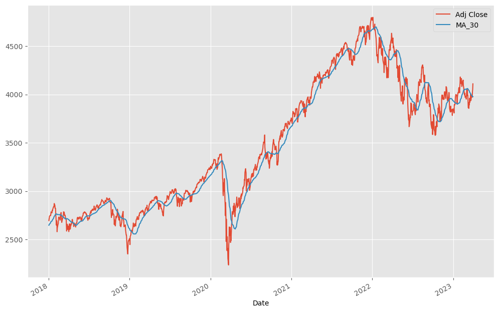

```python
sp500.loc['2018':, ['Adj Close', 'MA_30']].plot(figsize=(12,8))
```

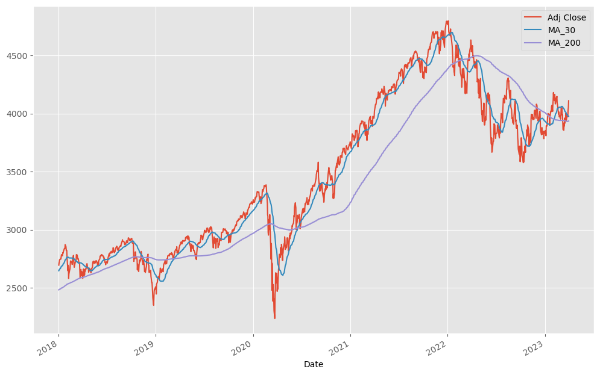

```python
# Comparing moving averages:
sp500['MA_200'] = sp500['Adj Close'].rolling(200).mean()
sp500.loc['2018':, ['Adj Close', 'MA_30','MA_200']].plot(figsize=(12,8))
```

## Monthly Returns

We can create a function to aggregate returns, using the fact that the return in each month is given by

\begin{equation} r_{t\rightarrow T} = \left\{\prod_{t=1}^T (1+r_t)\right\} - 1. \end{equation}

We can simulataneously calculate the volatility of the daily return series in each month.

`.agg()` applied on a DataFrame is documented [here](https://pandas.pydata.org/pandas-docs/stable/reference/api/pandas.DataFrame.agg.html?highlight=agg#pandas.DataFrame.agg)

```python
aggret = lambda ret: (1+ret).product() - 1

mrets = sp500['ret'].resample('M').apply([aggret, np.std])

mrets.head()
```

| Date | <lambda> | std |
| --- | --- | --- |
| 1950-01-31 | 0.023409 | 0.006933 |
| 1950-02-28 | 0.009971 | 0.005037 |
| 1950-03-31 | 0.004065 | 0.004737 |
| 1950-04-30 | 0.038751 | 0.005994 |
| 1950-05-31 | 0.045657 | 0.005476 |

```python
mrets = mrets.rename(columns={'<lambda>':'ret', 'std':'vol'})
mrets.describe()
```

|  | ret | vol |
| --- | --- | --- |
| count | 879.000000 | 879.000000 |
| mean | 0.007174 | 0.008495 |
| std | 0.042005 | 0.005207 |
| min | -0.217630 | 0.001923 |
| 25% | -0.017529 | 0.005364 |
| 50% | 0.009590 | 0.007187 |
| 75% | 0.035162 | 0.010027 |
| max | 0.163047 | 0.058850 |

### Return statistics by month

```python
mrets.groupby(mrets.index.month).mean()
```

| Date | ret | vol |
| --- | --- | --- |
| 1 | 0.010602 | 0.008336 |
| 2 | -0.000781 | 0.008089 |
| 3 | 0.011024 | 0.008804 |
| 4 | 0.015322 | 0.008292 |
| 5 | 0.002373 | 0.008169 |
| 6 | 0.000065 | 0.008244 |
| 7 | 0.012733 | 0.007763 |
| 8 | 0.000092 | 0.008274 |
| 9 | -0.006604 | 0.008827 |
| 10 | 0.009447 | 0.010389 |
| 11 | 0.017356 | 0.008957 |
| 12 | 0.014473 | 0.007793 |

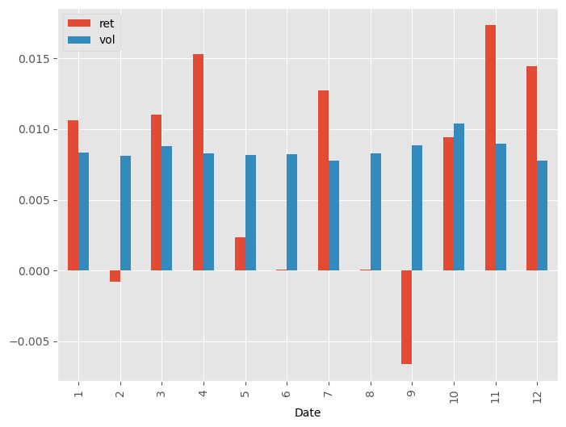

```python
# Plots the mean returns and volatility for each month
mrets.groupby(mrets.index.month).mean().plot(kind='bar')
```

## Autocorrelation of returns

Correlation, denoted $\rho$, measures the tendency of two series to move together around their respective means. It is a number that can range from $-1$ to $1$, and defined as

\begin{equation} \rho(x,y) = \frac{E[(x-\mu_x)(y-\mu_y)]}{\sigma_x \cdot \sigma_y}. \end{equation}

Autocorrelation simply applies the correlation measure to a single series, and measures whether the value at a point in time is correlated with some recent value. For example, the 1-period autocorrelation is

\begin{equation} \rho(y_t, y_{t-1}). \end{equation}

The autocorrelations below are close to 0 becuase of the efficient market hypothesis. Market prices move in a "random walk"

```python
mrets['ret'].autocorr()
```

```
0.008997320679603956
```

```python
sp500['ret'].autocorr()
```

```
-0.0013522800097191482
```

## Reading stock data from Yahoo!Finance using `pandas_datareader` (with the help of `yfinance`)

```python
import pandas_datareader as pdr
pdr.__version__
```

```
'0.10.0'
```

```python
import yfinance as yf
yf.__version__
```

```
'0.2.18'
```

```python
# You may need to install these as well:
# # install pandas_datareader:
# ! pip install pandas_datareader

# # upgrade pandas_datareader version (two ways):
# ! pip install --upgrade pandas_datareader
# ! pip install -U pandas_datareader

# # install yfinance:
# ! pip install yfinance

# # upgrade yfinance version (two ways):
# ! pip install --upgrade yfinance
# ! pip install -U yfinance
```

#### Download market data with `yfinance`:

```python
msft = yf.download('MSFT', start = '2023-01-01', end='2023-07-31')
msft
```

```
[*********************100%***********************]  1 of 1 completed
```

| Date | Open | High | Low | Close | Adj Close | Volume |
| --- | --- | --- | --- | --- | --- | --- |
| 2023-01-03 | 243.080002 | 245.750000 | 237.399994 | 239.580002 | 237.956345 | 25740000 |
| 2023-01-04 | 232.279999 | 232.869995 | 225.960007 | 229.100006 | 227.547363 | 50623400 |
| 2023-01-05 | 227.199997 | 227.550003 | 221.759995 | 222.309998 | 220.803360 | 39585600 |
| 2023-01-06 | 223.000000 | 225.759995 | 219.350006 | 224.929993 | 223.405594 | 43613600 |
| 2023-01-09 | 226.449997 | 231.240005 | 226.410004 | 227.119995 | 225.580765 | 27369800 |
| ... | ... | ... | ... | ... | ... | ... |
| 2023-07-24 | 345.850006 | 346.920013 | 342.309998 | 345.109985 | 344.380859 | 26678100 |
| 2023-07-25 | 347.109985 | 351.890015 | 345.070007 | 350.980011 | 350.238464 | 41637700 |
| 2023-07-26 | 341.440002 | 344.670013 | 333.109985 | 337.769989 | 337.056366 | 58383700 |
| 2023-07-27 | 340.480011 | 341.329987 | 329.049988 | 330.720001 | 330.021271 | 39635300 |
| 2023-07-28 | 333.670013 | 340.010010 | 333.170013 | 338.369995 | 337.655090 | 28484900 |

143 rows × 6 columns

#### Download market data with `pandas_datareader`:

(pandas_datareader can download data from a variety of data sources. However, recently, its [Yahoo!Finance API stopped working](https://stackoverflow.com/questions/68340334/pandas-datareader-not-working-with-yahoo-finance-api). The fix is to use `yf.pdr_override()` as shown bellow:)

```python
from pandas_datareader import data as pdr_dt
yf.pdr_override()

msft = pdr_dt.get_data_yahoo('MSFT', start='2017-04-23', end='2017-05-24')
msft
```

```
[*********************100%***********************]  1 of 1 completed
```

| Date | Open | High | Low | Close | Adj Close | Volume |
| --- | --- | --- | --- | --- | --- | --- |
| 2017-04-24 | 67.480003 | 67.660004 | 67.099998 | 67.529999 | 62.158028 | 29770000 |
| 2017-04-25 | 67.900002 | 68.040001 | 67.599998 | 67.919998 | 62.516998 | 30242700 |
| 2017-04-26 | 68.080002 | 68.309998 | 67.620003 | 67.830002 | 62.434177 | 26190800 |
| 2017-04-27 | 68.150002 | 68.379997 | 67.580002 | 68.269997 | 62.839180 | 34971000 |
| 2017-04-28 | 68.910004 | 69.139999 | 67.690002 | 68.459999 | 63.014065 | 39548800 |
| 2017-05-01 | 68.680000 | 69.550003 | 68.500000 | 69.410004 | 63.888504 | 31954400 |
| 2017-05-02 | 69.709999 | 69.709999 | 69.129997 | 69.300003 | 63.787235 | 23906100 |
| 2017-05-03 | 69.379997 | 69.379997 | 68.709999 | 69.080002 | 63.584743 | 28928000 |
| 2017-05-04 | 69.029999 | 69.080002 | 68.639999 | 68.809998 | 63.336212 | 21749400 |
| 2017-05-05 | 68.900002 | 69.029999 | 68.489998 | 69.000000 | 63.511105 | 19128800 |
| 2017-05-08 | 68.970001 | 69.050003 | 68.419998 | 68.940002 | 63.455879 | 18566100 |
| 2017-05-09 | 68.860001 | 69.279999 | 68.680000 | 69.040001 | 63.547913 | 22858400 |
| 2017-05-10 | 68.989998 | 69.559998 | 68.919998 | 69.309998 | 63.796425 | 17977800 |
| 2017-05-11 | 68.360001 | 68.730003 | 68.120003 | 68.459999 | 63.014065 | 28789400 |
| 2017-05-12 | 68.610001 | 68.610001 | 68.040001 | 68.379997 | 62.940422 | 18714100 |
| 2017-05-15 | 68.139999 | 68.480003 | 67.570000 | 68.430000 | 62.986454 | 31530300 |
| 2017-05-16 | 68.230003 | 69.440002 | 68.160004 | 69.410004 | 64.254707 | 34956000 |
| 2017-05-17 | 68.889999 | 69.099998 | 67.430000 | 67.480003 | 62.468048 | 30548800 |
| 2017-05-18 | 67.400002 | 68.129997 | 67.139999 | 67.709999 | 62.680958 | 25201300 |
| 2017-05-19 | 67.500000 | 68.099998 | 67.430000 | 67.690002 | 62.662445 | 26961100 |
| 2017-05-22 | 67.889999 | 68.500000 | 67.500000 | 68.449997 | 63.365990 | 16237600 |
| 2017-05-23 | 68.720001 | 68.750000 | 68.379997 | 68.680000 | 63.578922 | 15425800 |

#### Check for autocorrelation of the stock of interest:

```python
pdr_dt.get_data_yahoo('MSFT', '1980-01-01')['Adj Close'].pct_change().autocorr()
```

```
[*********************100%***********************]  1 of 1 completed
```

```
-0.017370125498702295
```

#### Observe a return histogram for the stock of interest. Is the return normally distributed?

```
[*********************100%***********************]  1 of 1 completed
```

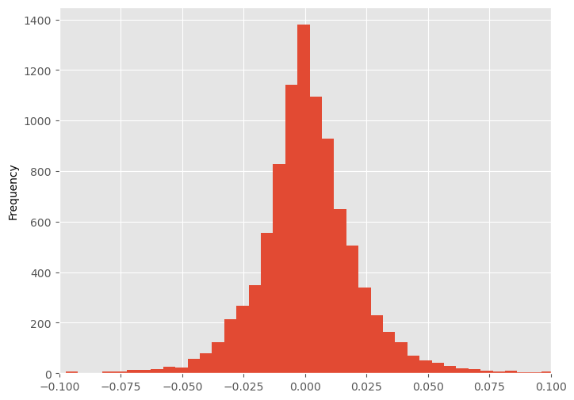

```python
pdr_dt.get_data_yahoo('MSFT', '1980-01-01')['Adj Close'].pct_change().plot(kind='hist', bins=100, xlim=(-.1, .1))
```

```python
tckrs = ['MSFT','META','IBM','C','GOOG','^DJI','^GSPC','^IXIC','^VIX']
for tic in tckrs:
    t, p = jarque_bera(pdr_dt.get_data_yahoo(tic, '1980-01-01')['Adj Close'].pct_change().dropna())
    print(f'The Jarque-Bera test statistic for {tic} is {t:.2f}, with a p-value of {p:.3f}.')
```

```
[*********************100%***********************]  1 of 1 completed
The Jarque-Bera test statistic for MSFT is 44483.20, with a p-value of 0.000.
[*********************100%***********************]  1 of 1 completed
The Jarque-Bera test statistic for META is 50848.68, with a p-value of 0.000.
[*********************100%***********************]  1 of 1 completed
The Jarque-Bera test statistic for IBM is 51843.60, with a p-value of 0.000.
[*********************100%***********************]  1 of 1 completed
The Jarque-Bera test statistic for C is 997672.48, with a p-value of 0.000.
[*********************100%***********************]  1 of 1 completed
The Jarque-Bera test statistic for GOOG is 17376.25, with a p-value of 0.000.
[*********************100%***********************]  1 of 1 completed
The Jarque-Bera test statistic for ^DJI is 52002.50, with a p-value of 0.000.
[*********************100%***********************]  1 of 1 completed
The Jarque-Bera test statistic for ^GSPC is 168467.08, with a p-value of 0.000.
[*********************100%***********************]  1 of 1 completed
The Jarque-Bera test statistic for ^IXIC is 33955.08, with a p-value of 0.000.
[*********************100%***********************]  1 of 1 completed
The Jarque-Bera test statistic for ^VIX is 92587.91, with a p-value of 0.000.
```

All of the p-values above are 0, meaning you can reject the null hypothesis that the distribution is normal.